# Validate, fetch, branch

Three small R packages for reproducible work with biological web services

Samuel Bharti

biobouncer, biohttp, bioclients

## Every app had the same two holes

Seven life-science Shiny apps, one author, and the same code rewritten in each.

7

apps

7

copies of “is this a gene?”

5

hand rolled API clients for the same service

0

that agreed with each other

Bad ids got through

`MLL` passed every regex. It was retired in 2013.

Outages became bugs

A 503 and “no such gene” both returned NULL.

That is not bad luck. That is a missing layer.

## The tryCatch soup

```r
fetch_gene <- function(symbol) {
  url <- paste0("https://mygene.info/v3/query?q=", symbol)
  tryCatch(
    {
      body <- jsonlite::fromJSON(url)
      if (length(body$hits) == 0) return(NULL)
      body$hits[1, ]
    },
    error = function(e) NULL
  )
}
```

no such gene

NULL

network down

NULL

HTTP 503

NULL

body was HTML

NULL

NULL erases why. A cache of NULLs poisons itself.

## Four walls

Bad ids get through

Shape is not existence. Nobody suggests a fix.

validate before you fetch

Outages crash apps

Or worse, they look like empty results.

a failure is a value

Rate limits look like bugs

429s retried in a tight loop, keys pasted into URLs.

limits belong in the client

Nothing reproduces

The answer depends on the day, the network, and the cache.

pin, cache, record

Each wall became a design rule, and each rule became a package.

## Three packages, one line each

biobouncer

Is this even an identifier? 50 sources, 4 modes, offline first. R, Python, JavaScript.

biohttp

Move the bytes and say what happened. One envelope, seven statuses, a cache that stores only successes.

bioclients

29 biological web services on biohttp. One table shape, one row per input.

biobouncer 0.2.0: CRAN, PyPI biohttp 0.1.2: CRAN biohttp 0.1.3: r-universe bioclients 0.1.1: r-universe

Validate, then transport, then fetch. Each one is separable, and none depends on Shiny.

## The family

[figure not shown]

## Is this even an identifier?

50

identifier sources

4

modes

3

languages, one corpus

```r
check_id(c("MONDO:0005148", "mondo:5148", "GO:0006915"), "mondo")
```

```
#>   input          valid  suggestion
#>   MONDO:0005148  TRUE   NA
#>   mondo:5148     FALSE  MONDO:0005148
#>   GO:0006915     FALSE  NA
```

pattern: is it well formed? cache: does it exist, in a dated snapshot? remote: does it exist right now?

Offline by default. One row per input. The suggestion is what the user meant.

## Repair, do not drop

```r
df$gene
```

```
#> [1] "TP53"  "MLL"  "CARS"  "BRCA2"  "EGFR"  "notagene"  NA
```

```r
report_id(df$gene, "hgnc", how = "cache")
```

[output not shown]

```r
repair_id(df$gene, "hgnc", how = "cache")
```

```
#> [1] "TP53"  "KMT2A"  "CARS1"  "BRCA2"  "EGFR"  "notagene"  NA
```

`MLL`

retired 2013, now `KMT2A`

`CARS`

renamed, now `CARS1`

`notagene`

unchanged. Nothing honest to replace it with.

`biobouncer_snapshots()`

HGNC 2026-07-07. Write it down.

The repair comes from a dated snapshot, not from a guess.

## A call returns a value

[figure not shown]

It never raises. Branch on a status, not on a condition.

[figure not shown]

## Seven statuses

ok no_data stale rate_limited timeout skipped error

```r
switch(res$status,
  ok           = render_table(res$data),
  no_data      = "Nothing found for that query.",
  skipped      = "Source paused, try again shortly.",
  rate_limited = paste("Slow down, retry in", res$retry_after, "s"),
  res$error
)
```

`no_data`

An answer. The source was reached and has nothing.

`skipped`

Nothing was sent. Evidence about the host, not the query.

`error`, `timeout`

The source did not answer. Say “try again”, not “not found”.

The soup collapsed three of these into one NULL. The UI was lying during every outage.

## The breaker rule

“Only a transport failure counts against a host. Any HTTP response at all, including a 500 and including a 200 whose body will not parse, proves the host is reachable and clears the count.”

from the biohttp vignette

3

failures to open

120

seconds cooldown

0

requests while open

A 503 proves the host is up. A hand rolled breaker that counts it turns a partial outage into a total one.

## 29 services, two halves each

[figure not shown]

29

services

134

exported functions

57

stored fixtures

0

Shiny dependencies

[figure not shown]

The parser is pure and fixture tested. The suite runs without a network.

## Reproducible by construction

offline modes

pattern and cache never touch the network

`how = "cache"`

dated snapshots

the version is a string you can cite

`version = "2026-07-07"`

success-only disk cache

fixed salt, long TTL, committed to the repo

`BIOHTTP_CACHE_DIR`

statuses, not exceptions

an outage is a column value in the output

`res$status`

Four mechanisms. Each one is a file or a string you can commit.

## Pipeline: eleven symbols, one table

```r
genes <- read.csv("data/genes.csv")          # TP53 BRAF NF1 ... MLL CARS TP53_HUMAN NA
chk   <- check_id(genes$symbol, "hgnc", how = "cache")
clean <- ifelse(chk$valid, chk$normalized, chk$suggestion)   # 9 survive
clean <- clean[!is.na(clean)]

ids   <- mygene_genes(clean)                 # one POST, 9 rows
cons  <- gnomad_constraints(clean)           # one GraphQL request, 9 rows
ot    <- lapply(ids$data$ensembl_gene,
                \(id) opentargets_gene_diseases(id, size = 3))

genes |>
  left_join(ids$data,  by = c(clean = "symbol")) |>
  left_join(cons$data, by = c(clean = "symbol"))
```

The whole chain fits on one slide because none of it is error handling.

## Second run

11

requests, first run

0

requests, second run

0.05 s

second run, all three services

```r
transport_stats()
```

```
#> [1] host dispatched retried rate_limited
#> <0 rows>
```

```r
identical(cons$data, cons2$data)
```

```
#> [1] TRUE
```

Cache hit evidence is a number, not a feeling.

## Pull the plug

3

transport failures recorded

1

status: skipped

0

crashes

```r
for (i in 1:3) breaker_record("mygene.info", reachable = FALSE)

down <- mygene_genes(c(clean, "ABL1"))
down$status
```

```
#> [1] "skipped"
```

```r
down$error
```

```
#> [1] "MyGene was skipped (host temporarily unreachable)."
```

The table still builds. The MyGene columns are NA and a status column says why.

## The Shiny app

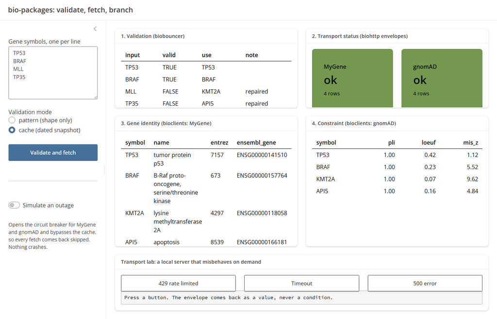

## Same app, the network gone

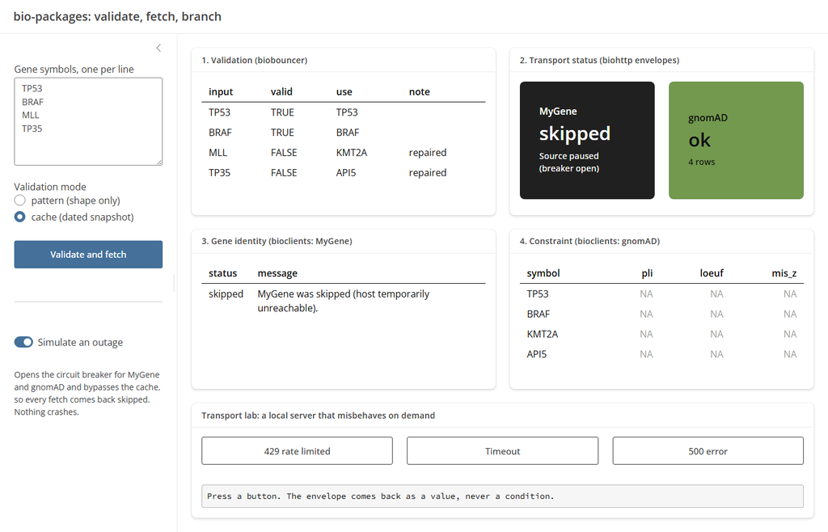

## What is on CRAN and what is not

CRAN, PyPI

**biobouncer 0.2.0**

```r
install.packages("biobouncer")
```

```bash
pip install biobouncer
```

CRAN 0.1.2 r-universe 0.1.3

**biohttp**

```r
install.packages("biohttp")
```

0.1.3 adds `retry_after`, batched retry, `transport_stats()`.

r-universe

**bioclients 0.1.1**

```r
pak::pak(
  "samuelbharti/bioclients/pkg-r")
```

The `/pkg-r` suffix is required.

Say the versions once, out loud, and nobody installs the wrong one.

## Start here

**Tonight**

```r
install.packages(c("biobouncer", "biohttp"))
install.packages("bioclients",
  repos = "https://samuelbharti.r-universe.dev")

library(biobouncer); library(bioclients)
clean <- repair_id(c("MLL", "TP53", "notagene"), "hgnc", how = "cache")
mygene_genes(clean)$status
```

**This talk**

- Four tutorials, one per package and one pipeline, all render offline
- A Shiny app under 200 lines
- A committed transport cache and the scripts that warm and verify it

Docs hub: `samuelbharti.com/biobouncer`, `/biohttp`, `/bioclients`

Validate, then fetch, then branch on what came back.

## Questions

[figure not shown]